```python
# Script name: Assignment 12
# Purpose of script: Assignment 12
# Author: Minh-Thy Tyler
# Date Created:
# 12/01/2022
# Notes: N/A
# ---------------------------

import numpy as np
import pandas as pd
import os
import random
import matplotlib.pyplot as plt
import statsmodels.formula.api as smf
from scipy import stats
import seaborn as sns
import patsy as pt
import statsmodels.stats.api as sms
import statsmodels.api as sm
import statistics

# Set up working directory
directory_path = '/Users/minh-thytyler/Desktop/2022-2023/ECON 320/HW' # use / instead of \ or use \ but insert r before (for instance: r'C:\your-directory-path')
os.chdir(directory_path)
```

# Part 1

```python
#Perform a data generating process of y = B0 + B1 * x + uprime
birthday = '08182001'
rng = np.random.RandomState(int(birthday))

beta0=9
beta1=8

x = rng.normal(loc=10,scale=1,size=1000000)
u = rng.normal(loc=0,scale=1,size=1000000)
#making u a function of x
uprime = x*u
y = beta0 +beta1*x +uprime

#data variable is in a data frame

data ={"x": x, "u":u,"y":y, 'uprime':uprime}
data = pd.DataFrame(data)
print(data.head())
print(data.describe())
```

```
           x         u           y     uprime
0  10.938747 -0.971789   85.879819 -10.630158
1   9.373442  0.025316   84.224838   0.237302
2   9.834372 -0.255070   85.166520  -2.508455
3  10.289993 -0.549509   85.665495  -5.654446
4  10.603579  0.984107  104.263681  10.435052
                    x               u               y          uprime
count  1000000.000000  1000000.000000  1000000.000000  1000000.000000
mean         9.998355       -0.000556       88.979780       -0.007063
std          1.001314        1.001204       12.848642       10.059232
min          5.170482       -4.927307       36.210090      -53.719248
25%          9.322126       -0.675628       80.055947       -6.702538
50%          9.998102       -0.001628       88.501145       -0.016307
75%         10.674147        0.674362       97.364511        6.686365
max         15.224590        4.974452      164.884965       52.502017
```

## **a)**

**Heteroskedastic graph using u'**

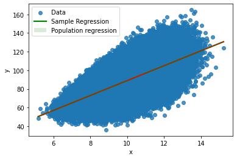

```python
res = smf.ols("y~x", data = data).fit()
sns.regplot(x = "x",y = "y", data = data, line_kws={'color':'green'});
plt.plot(data["x"],beta0+beta1*data["x"],':r');
plt.legend(["Data",'Sample Regression',"Population regression"],loc='upper left');
```

**Homoskedasstic graph using u**

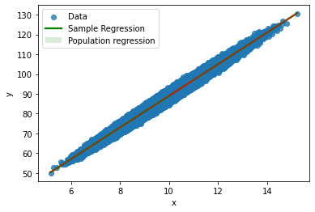

```python
#Perform a data generating process of y = B0 + B1 * x + u
birthday = '08182001'
rng = np.random.RandomState(int(birthday))

beta0=9
beta1=8

x = rng.normal(loc=10,scale=1,size=1000000)
u = rng.normal(loc=0,scale=1,size=1000000)


y = beta0 +beta1*x +u

#data variable is in a data frame

datas ={"x": x, "u":u,"y":y}
datas = pd.DataFrame(datas)

res1 = smf.ols("y~x", data = datas).fit()
sns.regplot(x = "x",y = "y", data = datas, line_kws={'color':'green'});
plt.plot(datas["x"],beta0+beta1*datas["x"],':r');
plt.legend(["Data",'Sample Regression',"Population regression"],loc='upper left');
```

We are still using algebraic properties of OLS, but we are not using OLS is BLUE under heteroskedastictic. OLS is BLUE only when it is homoskedastic.

## **b)**

```python
from statsmodels.compat import lzip
#BP test
#estimating model for hetero
test = sm.stats.diagnostic.het_breuschpagan(res.resid, res.model.exog)
name = ['Langrange Multiplier statistic', 'p-value', 'f-value','f p-value']
pd.DataFrame(lzip(name,test))
```

|  | 0 | 1 |
| --- | --- | --- |
| 0 | Langrange Multiplier statistic | 18231.139369 |
| 1 | p-value | 0.000000 |
| 2 | f-value | 18569.648762 |
| 3 | f p-value | 0.000000 |

```python
#homo
test = sm.stats.diagnostic.het_breuschpagan(res1.resid, res1.model.exog)
name = ['Langrange Multiplier statistic', 'p-value', 'f-value','f p-value']
pd.DataFrame(lzip(name,test))
```

|  | 0 | 1 |
| --- | --- | --- |
| 0 | Langrange Multiplier statistic | 0.652209 |
| 1 | p-value | 0.419324 |
| 2 | f-value | 0.652208 |
| 3 | f p-value | 0.419325 |

The p-value and p-value for the f test under heteroskedasticity is very low and we would reject the null hypothesis. The p-value and p-value for the f test under homoskedasticity is high and we would fail to reject the null hypothesis. Heteroskedasticity tends to produce p-values that are smaller than they should be. This is because heteroskedasticity increases the variance of the coefficient estimates but the OLS procedure doesn't detect the increase.

## **c)**

```python
beta_1 = []
for i in range(1000):
    sample_df = data.sample(n=1000, replace = True, random_state = i)
    het = smf.ols('y~x', data=sample_df).fit(cov_type='HC0')
    beta_1.append(het.params[1])
reg_het = pd.DataFrame({'beta1':beta_1})
print(reg_het.head())
```

```
      beta1
0  8.227087
1  8.214330
2  8.177066
3  7.779881
4  8.621313
```

```python
print("The variance of sample beta1 in DGP with u'",np.var(reg_het))
```

```
The variance of sample beta1 in DGP with u' beta1    0.098284
dtype: float64
```

```python
#homo DGP done at beginning
beta_1h = []
for i in range(1000):
    sample_df = datas.sample(n=1000, replace = True, random_state = i)
    hom= smf.ols('y~x', data=sample_df).fit(cov_type='HC0')
    beta_1h.append(hom.params[1])
reg_hom = pd.DataFrame({'beta1':beta_1h})
print(reg_hom.head())
```

```
      beta1
0  8.009406
1  8.027901
2  8.019268
3  7.988183
4  8.060354
```

```python
print("The variance of sample beta1 in DGP with u",np.var(reg_hom))
```

```
The variance of sample beta1 in DGP with u beta1    0.000952
dtype: float64
```

The variances of both DGPs are the same as the ones found in Assignment 11. The empirical variance under homoskedasticity is .000952. This makes sense, because the variance under homoskedasticity is the smallest variance it could be and OLS is BLUE. The sample variances should be the same across residuals. The expected variance under heteroskedasticty is .09824.This variance is greater than the variance under homoskedasticity and OLS is not BLUE. The sample variances under heteroskedasticity varies wildly across residuals, but the reason why it did not vary in this case is because the random seed is the same in assignment 11 and assignment 12 and it was the same samples.